# Transform Data

# dplyr

## Your Turn 1

```r
babynames%>%filter(n == 9680)
```

| year | sex | name | n | prop |
| --- | --- | --- | --- | --- |
| 1939 | M | Gary | 9680 | 0.00854247 |
| 1983 | M | Dustin | 9680 | 0.00519500 |

```r
babynames%>%
  filter(year == 2015, sex == "M") %>%
  select(name, n) %>%
  arrange(desc(n))
```

| name | n |
| --- | --- |
| Noah | 19613 |
| Liam | 18355 |
| Mason | 16610 |
| Jacob | 15938 |
| William | 15889 |
| Ethan | 15069 |
| James | 14799 |
| Alexander | 14531 |
| Michael | 14413 |
| Benjamin | 13692 |

[output cut: 990 more lines]

Use `%>%` to write a sequence of functions that:

1. Filters babynames to just the girls that were born in 2017, *then…*
2. Selects the `name` and `n` columns, *then…*
3. Arranges the results so that the most popular names are near the top. %>% is the “pipe” it is a “then” to layer codes or steps can do it as an onion ((())) but that gets confusing the pipe allows you to carry code to the next step without having to assign everytime still has to be in the same chunk %>% ctrl + shift + M

```r
babynames %>%
  filter(year == 2017, sex == "F") %>%
  select(name, n) %>%
  arrange(desc(n))
```

| name | n |
| --- | --- |
| Emma | 19738 |
| Olivia | 18632 |
| Ava | 15902 |
| Isabella | 15100 |
| Sophia | 14831 |
| Mia | 13437 |
| Charlotte | 12893 |
| Amelia | 11800 |
| Evelyn | 10675 |
| Abigail | 10551 |

[output cut: 990 more lines]

## Your Turn 2

1. Trim `babynames` to just the rows that contain **your** `name` and **your** `sex`
2. Trim the result to just the columns that will appear in your graph (not strictly necessary, but useful practice)
3. Plot the results as a line graph with `year` on the x axis and `prop` on the y axis

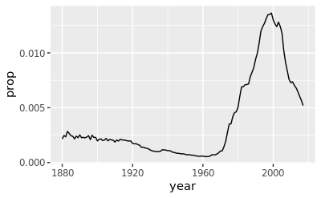

```r
babynames %>%
  filter(name == "Emily", sex == "F") %>%
  select(year, prop) %>%
  ggplot() +
  geom_line(mapping = aes(year, prop))
```

## Your Turn 3

Copmplete the code below to extract the rows where `name == "Khaleesi"`. Then use `summarise()` and `sum()` and `min()` to find:

1. The total number of children named Khaleesi
2. The first year Khaleesi appeared in the data

*(Hint: Be sure to remove each `_` before running the code)*

```r
babynames %>%
  filter(name == "Khaleesi") %>%
  summarize(total = sum(n), first = min(year))
```

| total | first |
| --- | --- |
| 1964 | 2011 |

## Your Turn 4

Use `group_by()`, `summarise()`, and `arrange()` to display the ten most popular names. Compute popularity as the *total* number of children of a single gender given a name.

*(Hint: Be sure to remove each `_` before running the code)*

```r
babynames %>%
  group_by(name, sex) %>%
  summarize(total = sum(n)) %>%
  arrange(desc(total))
```

| name | sex | total |
| --- | --- | --- |
| James | M | 5150472 |
| John | M | 5115466 |
| Robert | M | 4814815 |
| Michael | M | 4350824 |
| Mary | F | 4123200 |
| William | M | 4102604 |
| David | M | 3611329 |
| Joseph | M | 2603445 |
| Richard | M | 2563082 |
| Charles | M | 2386048 |

[output cut: 990 more lines]

## Your Turn 5

Fill in the blanks to: Rank each name *within its year and sex*.

*(Hint: Be sure to remove each `_` before running the code)*

```r
babynames %>%
  group_by(year, sex) %>%
  mutate(rank = min_rank(desc(prop))) %>%
  filter(rank == 1)
```

| year | sex | name | n | prop | rank |
| --- | --- | --- | --- | --- | --- |
| 1880 | F | Mary | 7065 | 0.07238359 | 1 |
| 1880 | M | John | 9655 | 0.08154561 | 1 |
| 1881 | F | Mary | 6919 | 0.06999140 | 1 |
| 1881 | M | John | 8769 | 0.08098299 | 1 |
| 1882 | F | Mary | 8148 | 0.07042655 | 1 |
| 1882 | M | John | 9557 | 0.07831617 | 1 |
| 1883 | F | Mary | 8012 | 0.06673386 | 1 |
| 1883 | M | John | 8894 | 0.07907394 | 1 |
| 1884 | F | Mary | 9217 | 0.06699083 | 1 |
| 1884 | M | John | 9388 | 0.07648813 | 1 |

[output cut: 266 more lines]

# Take aways

- Make tables of summaries with `summarise()`
- Make new variables, with `mutate()`
- Do groupwise operations with `group_by()`
- Connect operations with `%>%`